# IODS course project

Guilherme Varro

# RStudio Exercise 1

Chapter 1. “I am taking this course in order to learn and analyse data for my Master’s Thesis research. The link to my github repository is: (https://github.com/guinv8/IODS-project)”

# Regression Analysis

**The following dataset is being used for the purpose of this statistical analysis: *Learning2014*. The dataset is the result of the research “International survey of Approaches to Learning, made possible by Teachers, available at the following URL:http://www.helsinki.fi/~kvehkala/JYTmooc/JYTOPKYS3-meta.txt”. The data was collected during the period of 3.12.2014 - 10.1.2015 by Kimmo Vehkalahti**

**It is the objective of this report to analyse the data through R, with a concise explanation of each step and codes used.**

**The research consisted of 183 observations and 7 variables (Gender, Age, Attitude, Deep Learning, Strategic Learning, Surface Learning and Points). For analytical reasons, only Points above zero are being counted at this analysis, limiting the total number of observations to 166.**

**1) Structure of the Data**

The following code is used to analyse the structure of the data, such as how many variables and total number of observations.

```
## 'data.frame':    166 obs. of  7 variables:
##  $ gender  : Factor w/ 2 levels "F","M": 1 2 1 2 2 1 2 1 2 1 ...
##  $ Age     : int  53 55 49 53 49 38 50 37 37 42 ...
##  $ Attitude: int  37 31 25 35 37 38 35 29 38 21 ...
##  $ deep    : num  3.75 2.88 3.88 3.5 3.75 ...
##  $ stra    : num  3.38 2.75 3.62 3.12 3.62 ...
##  $ surf    : num  2.58 3.17 2.25 2.25 2.83 ...
##  $ Points  : int  25 12 24 10 22 21 21 31 24 26 ...
```

**2) Dimension of the data**

The following code is used to analyse the dimension of the data, in this case 166x7 (166 Observations x 7 variables)

```
## [1] 166   7
```

**3) Plotting the data.**

The following graph shows the relation between student’s Attitude and their score (points) in university. The blue dots represent male students, while de red dots represent female students. The simple regression line represents the variety of the data

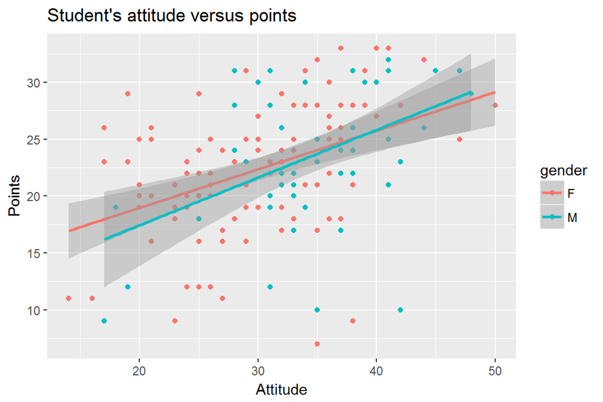

**4) Variable Matrix**

The following matrix shows us the 7 variables and how they relate to eachother. It is possible, for example to relate the importance of deep learning, strategic learning and student attitude with points.

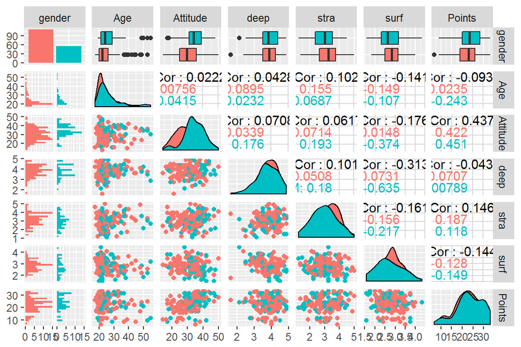

**5) Regression Analysis**

*Regression 1 - Attitude, Strategic Learning and Surface Learning*

Analysing the multiple regression skecthed, one can come to the conclusion that some parameters (Surface learning, Attitude and Strategic Learning), such as Surface Learning have no statistically relevant relationship with the variable Points. Attitude is by far, according to the hyphothesis test (closest value to zero), the variable most related to high points.

```
##
## Call:
## lm(formula = Points ~ Attitude + stra + surf, data = learning2014)
##
## Coefficients:
## (Intercept)     Attitude         stra         surf
##     11.0171       0.3395       0.8531      -0.5861
```

```
##
## Call:
## lm(formula = Points ~ Attitude + stra + surf, data = learning2014)
##
## Residuals:
##      Min       1Q   Median       3Q      Max
## -17.1550  -3.4346   0.5156   3.6401  10.8952
##
## Coefficients:
##             Estimate Std. Error t value Pr(>|t|)
## (Intercept) 11.01711    3.68375   2.991  0.00322 **
## Attitude     0.33952    0.05741   5.913 1.93e-08 ***
## stra         0.85313    0.54159   1.575  0.11716
## surf        -0.58607    0.80138  -0.731  0.46563
## ---
## Signif. codes:  0 '***' 0.001 '**' 0.01 '*' 0.05 '.' 0.1 ' ' 1
##
## Residual standard error: 5.296 on 162 degrees of freedom
## Multiple R-squared:  0.2074, Adjusted R-squared:  0.1927
## F-statistic: 14.13 on 3 and 162 DF,  p-value: 3.156e-08
```

*Regression 2 - Attitude and Strategic Learning*

On the following regression, I’ve taken out the variable Surface Learning, only comparing Attitude with Strategic Learning. Attitude maintains itself as the most significant variable when related to Points, according to the hypothesis test.

```
##
## Call:
## lm(formula = Points ~ Attitude + stra, data = learning2014)
##
## Coefficients:
## (Intercept)     Attitude         stra
##      8.9729       0.3466       0.9137
```

```
##
## Call:
## lm(formula = Points ~ Attitude + stra, data = learning2014)
##
## Residuals:
##      Min       1Q   Median       3Q      Max
## -17.6436  -3.3113   0.5575   3.7928  10.9295
##
## Coefficients:
##             Estimate Std. Error t value Pr(>|t|)
## (Intercept)  8.97290    2.39591   3.745  0.00025 ***
## Attitude     0.34658    0.05652   6.132 6.31e-09 ***
## stra         0.91365    0.53447   1.709  0.08927 .
## ---
## Signif. codes:  0 '***' 0.001 '**' 0.01 '*' 0.05 '.' 0.1 ' ' 1
##
## Residual standard error: 5.289 on 163 degrees of freedom
## Multiple R-squared:  0.2048, Adjusted R-squared:  0.1951
## F-statistic: 20.99 on 2 and 163 DF,  p-value: 7.734e-09
```

*Regression 3 - Attitude*

Analysisng solely Attitude, we can come up with the conclusion that high student attitude results in high points.

```
##
## Call:
## lm(formula = Points ~ Attitude, data = learning2014)
##
## Coefficients:
## (Intercept)     Attitude
##     11.6372       0.3525
```

```
##
## Call:
## lm(formula = Points ~ Attitude, data = learning2014)
##
## Residuals:
##      Min       1Q   Median       3Q      Max
## -16.9763  -3.2119   0.4339   4.1534  10.6645
##
## Coefficients:
##             Estimate Std. Error t value Pr(>|t|)
## (Intercept) 11.63715    1.83035   6.358 1.95e-09 ***
## Attitude     0.35255    0.05674   6.214 4.12e-09 ***
## ---
## Signif. codes:  0 '***' 0.001 '**' 0.01 '*' 0.05 '.' 0.1 ' ' 1
##
## Residual standard error: 5.32 on 164 degrees of freedom
## Multiple R-squared:  0.1906, Adjusted R-squared:  0.1856
## F-statistic: 38.61 on 1 and 164 DF,  p-value: 4.119e-09
```

**6) R-Squared Analysis**

On the first analysis, which included the variable SURFACE LEARNING, R-Squared was within the values of 0.2074. Comparing it with the second analysis with no Surface Learning Variable, the value was of 0.2048. Now, if we go even further and remove the Strategic Learning Variable, as we did on the third analysis, the R-Squared value would be 0.1906. This exercise shows the impact of the variables on the regressionanalysis.

**7) Statistical Models**

Taking the consideration MultipleRegression2, which uses variables Attitude AND Strategic Learning, it is possible to analyse the following statistical models:

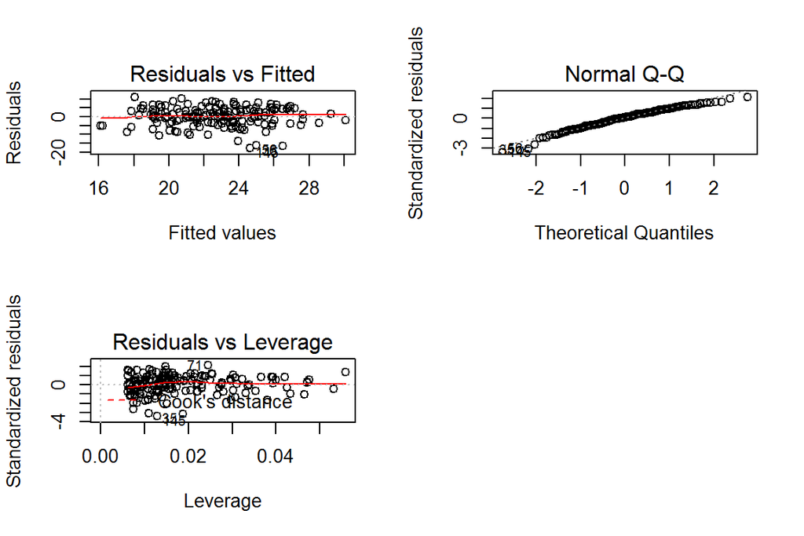

*Residual vs Fitted*

On this first plot, it is alright to consider that the values are scattered on an even manner , with little error exceptions. We can consider this plot a good model.

*Normal Q-Q*

Very few values outstanding from the main regression line. Good model of observation.

*Residual vs Leverage*

Good distribution of values throughout the chart. Good statistical model

# Logistic Regression

**The following dataset is being used for the purpose of this statistical analysis: *alc*. The dataset is the result of the research “Student Alcohol Cumsumption, available through AVI Machine Learning**

**It is the objective of this report to analyse the data through R, with a concise explanation of each step and codes used.**

**The research consisted of 382 observations and 35 variables**

**1) Structure of the Data** The following code is used to analyse the structure of the data, such as how many variables and total number of observations. Total: 382x35

```
## [1] 382  35
```

```
## 'data.frame':    382 obs. of  35 variables:
##  $ school    : Factor w/ 2 levels "GP","MS": 1 1 1 1 1 1 1 1 1 1 ...
##  $ sex       : Factor w/ 2 levels "F","M": 1 1 1 1 1 2 2 1 2 2 ...
##  $ age       : int  18 17 15 15 16 16 16 17 15 15 ...
##  $ address   : Factor w/ 2 levels "R","U": 2 2 2 2 2 2 2 2 2 2 ...
##  $ famsize   : Factor w/ 2 levels "GT3","LE3": 1 1 2 1 1 2 2 1 2 1 ...
##  $ Pstatus   : Factor w/ 2 levels "A","T": 1 2 2 2 2 2 2 1 1 2 ...
##  $ Medu      : int  4 1 1 4 3 4 2 4 3 3 ...
##  $ Fedu      : int  4 1 1 2 3 3 2 4 2 4 ...
##  $ Mjob      : Factor w/ 5 levels "at_home","health",..: 1 1 1 2 3 4 3 3 4 3 ...
##  $ Fjob      : Factor w/ 5 levels "at_home","health",..: 5 3 3 4 3 3 3 5 3 3 ...
##  $ reason    : Factor w/ 4 levels "course","home",..: 1 1 3 2 2 4 2 2 2 2 ...
##  $ nursery   : Factor w/ 2 levels "no","yes": 2 1 2 2 2 2 2 2 2 2 ...
##  $ internet  : Factor w/ 2 levels "no","yes": 1 2 2 2 1 2 2 1 2 2 ...
##  $ guardian  : Factor w/ 3 levels "father","mother",..: 2 1 2 2 1 2 2 2 2 2 ...
```

[output cut: 21 more lines]

**Dimensions of the Data** For the following exercise, three graphs represent three variables that directly impact the student’s comsumption of alcohol.

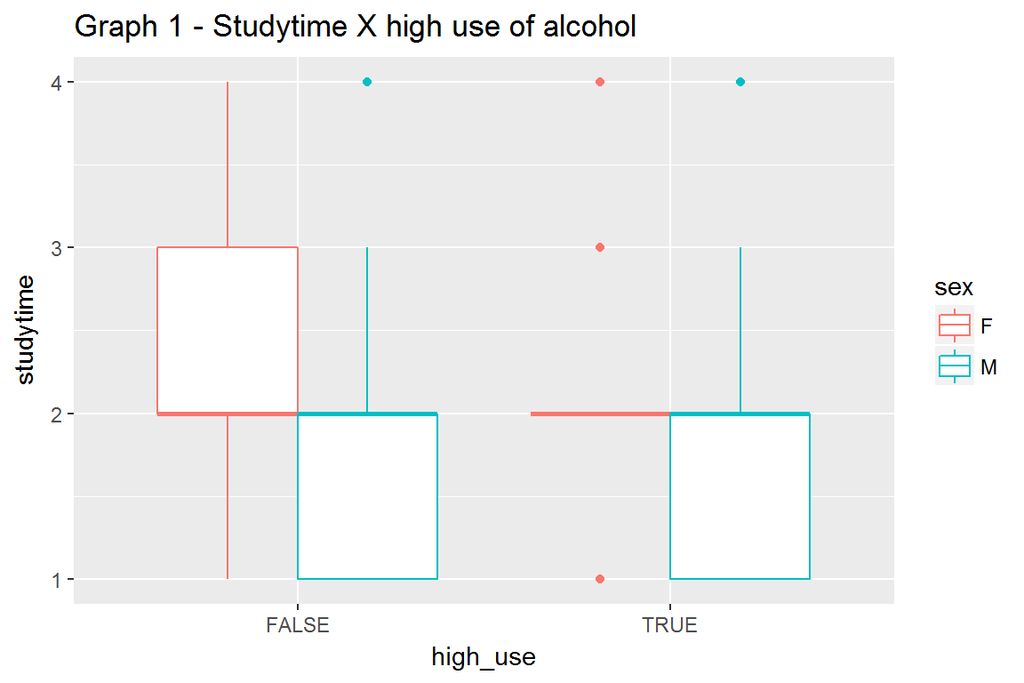

*Family Relations x Alcohol COnsumption*

The following graph shows the relationship between Family relationship and high use of alcohol. This supports the assumption that family relationships are determinant on the quantity of alcohol being consumed by the student (more as the relationship worsens)

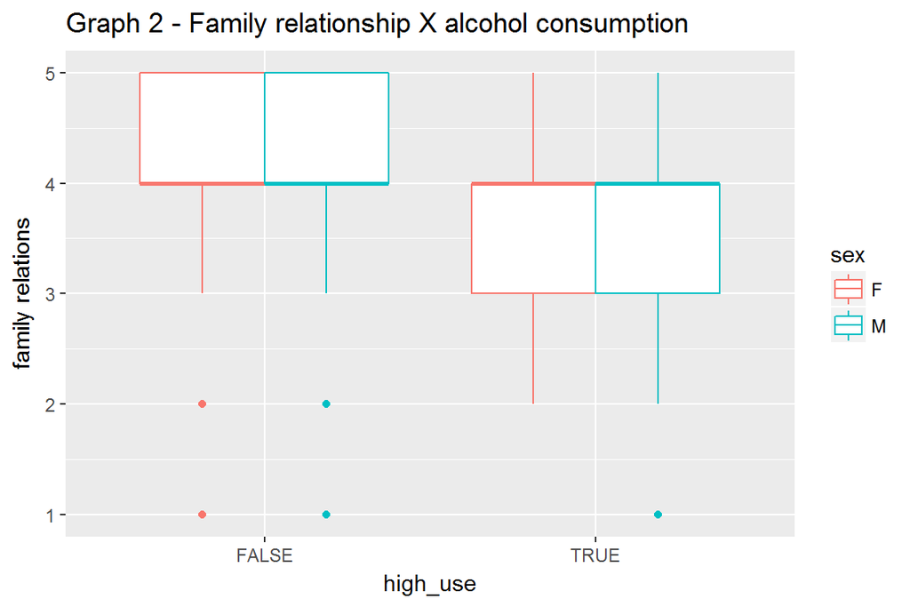

*Free Time x Alcohol COnsumption*

The following graph shows the relationship between free time and alcohol abuse. On this case, specially on girls, the statement that the higher amount of free time influences negatively on the amount of alcohol being consumed can be considered true.

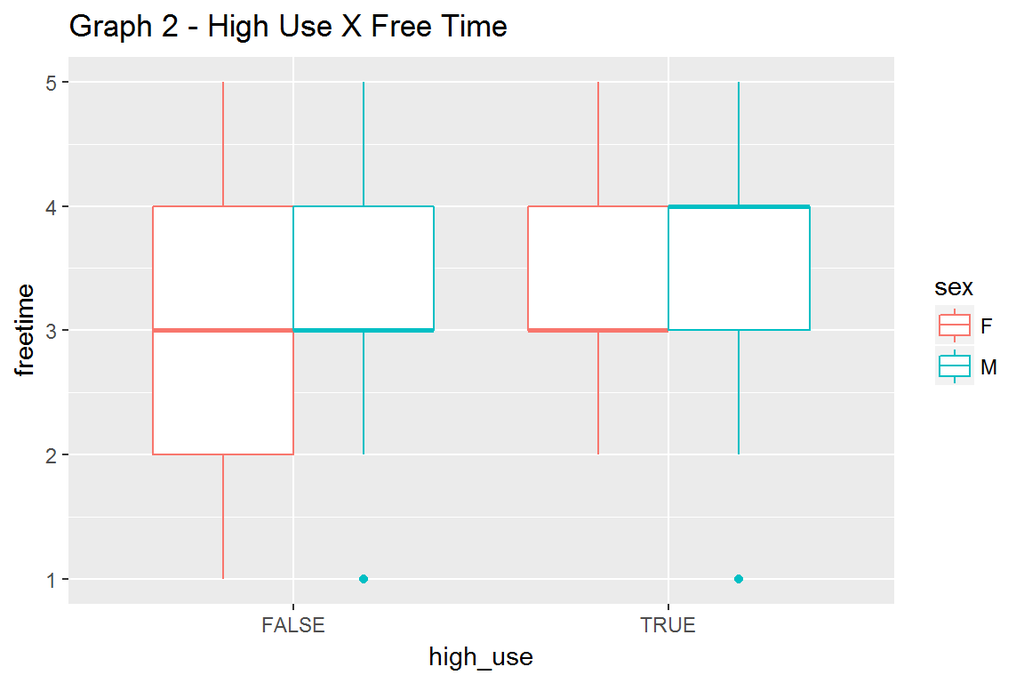

**Logistic Regression**

This model predicts the probability of free time, family relations, sex and studytime when related to the high use of alcohol.

```
##
## Call:
## glm(formula = high_use ~ freetime + famrel + sex + studytime,
##     family = "binomial", data = alc)
##
## Deviance Residuals:
##     Min       1Q   Median       3Q      Max
## -1.7003  -0.8583  -0.6046   1.1678   2.1170
##
## Coefficients:
##             Estimate Std. Error z value Pr(>|z|)
## (Intercept)   0.1308     0.6726   0.194  0.84583
## freetime      0.3101     0.1257   2.467  0.01362 *
## famrel       -0.3847     0.1285  -2.994  0.00275 **
## sexM          0.6371     0.2518   2.530  0.01141 *
## studytime    -0.4468     0.1573  -2.840  0.00450 **
## ---
## Signif. codes:  0 '***' 0.001 '**' 0.01 '*' 0.05 '.' 0.1 ' ' 1
##
## (Dispersion parameter for binomial family taken to be 1)
##
##     Null deviance: 462.21  on 381  degrees of freedom
## Residual deviance: 423.71  on 377  degrees of freedom
## AIC: 433.71
##
## Number of Fisher Scoring iterations: 4
```

According to the following statement, we an agree that free time and family relations do impact on high use of alcohol.

```
## (Intercept)    freetime      famrel        sexM   studytime
##   0.1307898   0.3101352  -0.3847478   0.6370787  -0.4468016
```

*Data Prediction*

Verifying the prediction power of our model when new data is added, and its tendency or not to be an avid drinker. The prediction should be done through binary form, with the set value of 0.5 as a measure. Any value higher than 0.5 appoints the new piece of data as probably being a high consumer of alcohol.

```
##         prediction
## high_use FALSE TRUE
##    FALSE   250   20
##    TRUE     92   20
```

*Prediction Graph*

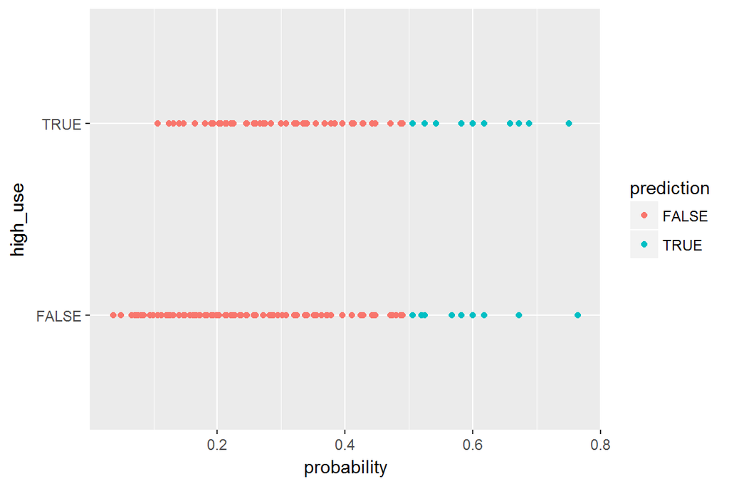

```
##         prediction
## high_use      FALSE       TRUE        Sum
##    FALSE 0.65445026 0.05235602 0.70680628
##    TRUE  0.24083770 0.05235602 0.29319372
##    Sum   0.89528796 0.10471204 1.00000000
```

*Testing Errors*

The current testing error value of this data is 29%. This means that 29% of the predictions could not be correct.

```
## [1] 0.2931937
```